# Web Design Homework - Web Visualization Dashboard (Latitude)

### Considerations

- You may use the weather data or choose another dataset. Alternatively, you may use the included cities dataset and pull the images from the assets folder.
- You must use Bootstrap. This includes using the Bootstrap `navbar` component for the header on every page, the bootstrap table component for the data page, and the Bootstrap grid for responsiveness on the comparison page.
- You must deploy your website to GitHub pages, with the website working on a live, publicly accessible URL as a result.
- Be sure to use a CSS media query for the navigation menu.
- Be sure your website works at all window widths/sizes.
- Feel free to take some liberty in the visual aspects, but keep the core functionality the same.

### Bonuses

- Use a different dataset! The requirements above still hold, but make it your own.
- Use a Bootstrap theme to customize your website. You may use a tool like [Bootswatch](https://bootswatch.com/). Make it look snazzy, give it some attitude. If using this, be sure you also meet all of the requirements listed above.
- Add extra visualizations! The more comparisons the better, right?
- Use meaningful glyphicons next to links in the header.
- Have visualization navigation on every visualizations page with an active state. See the screenshots below.

### Screenshots

This section contains screenshots of each page that must be built, at varying screen widths. These are a guide; you can meet the requirements without having the pages look exactly like the below images.

#### Landing page

Large screen:

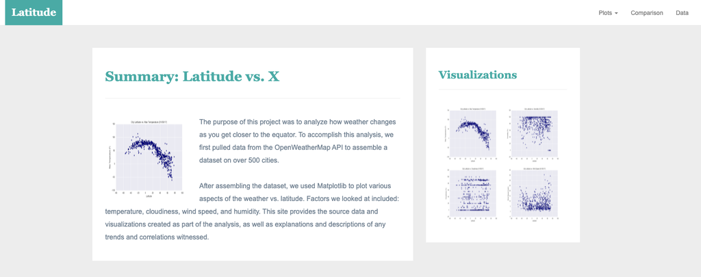

Landing page large screen

Small screen:

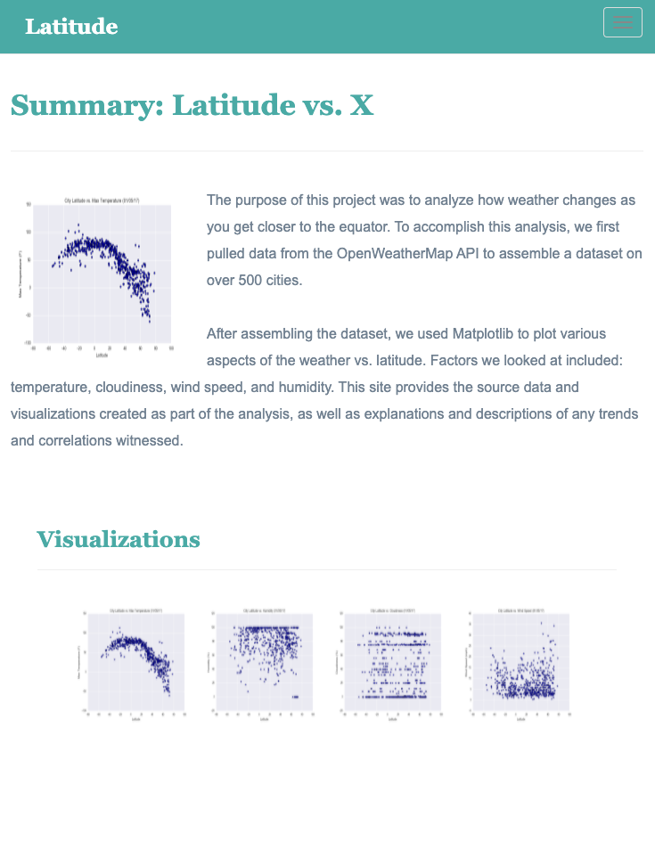

#### Comparisons page

Large screen:

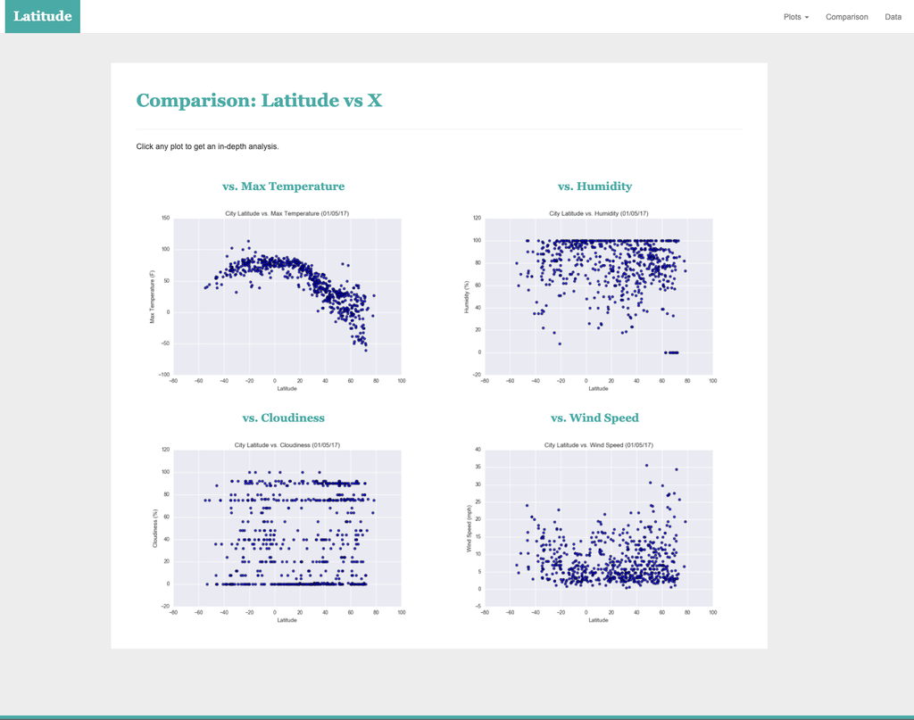

comparison page large screen

Small screen:

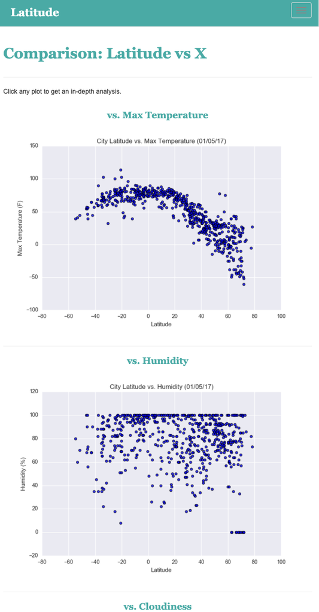

comparison page small screen

#### Data page

Large screen:

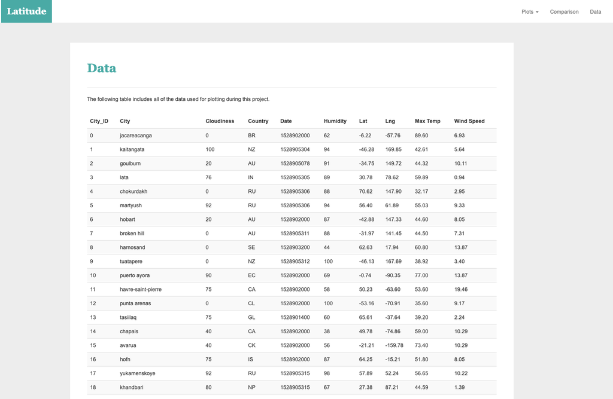

data page large screen

Small screen:

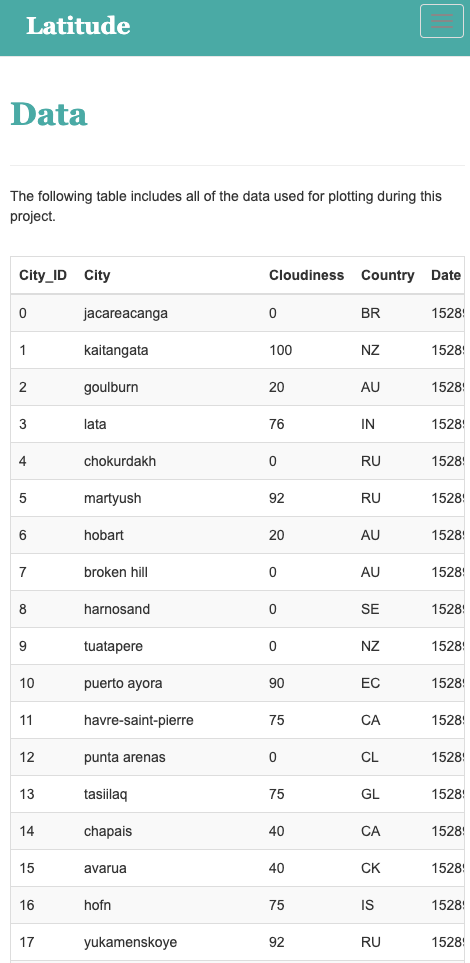

data page small screen

#### Visualization pages

You’ll build four of these, one for each visualization. Here’s an example of one:

Large screen:

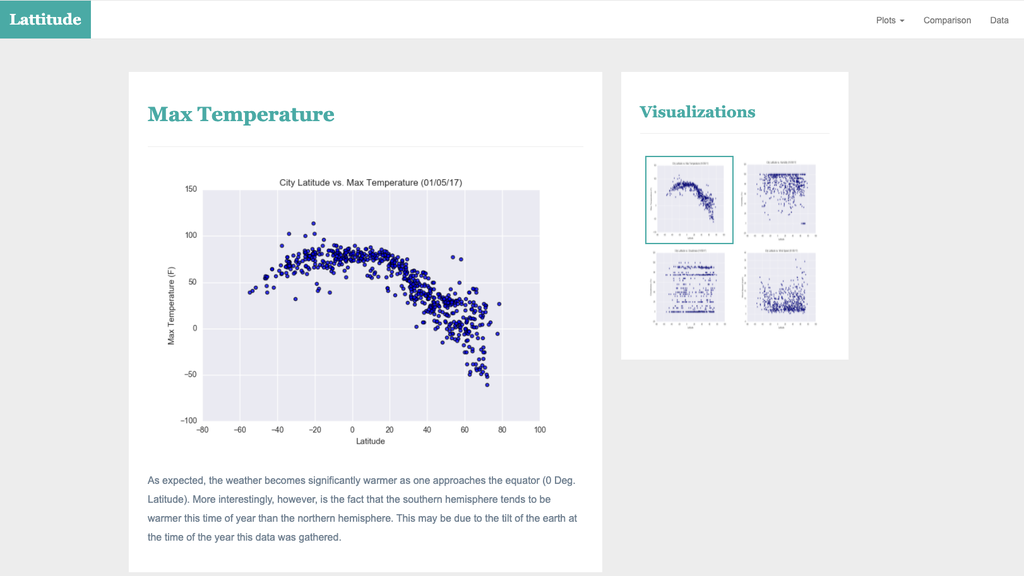

visualize page large screen

Small screen:

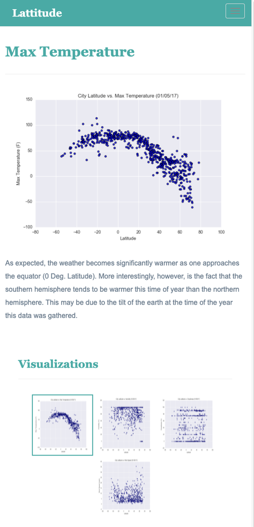

visualize page small screen

#### Navigation menu

Large screen:

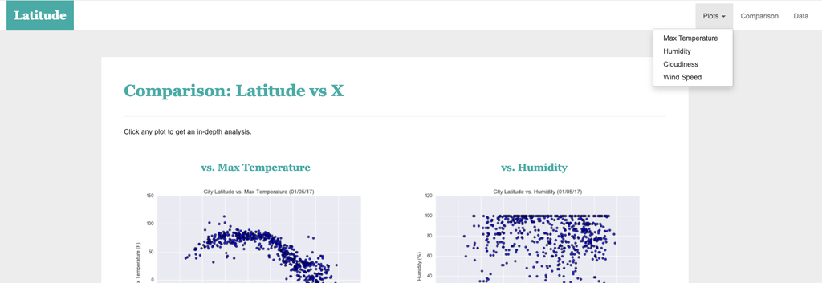

Small screen:

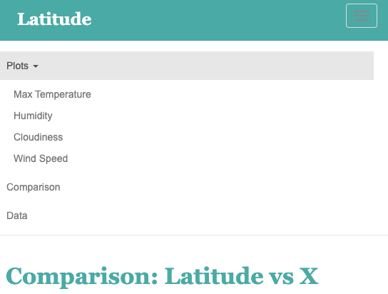

### Copyright

Trilogy Education Services © 2019. All Rights Reserved.